# Monthly Allocation Brief

Global Investment Advisor

Published

September 23, 2026

## Executive Summary

**Key Metrics at a Glance**

As of September 23, 2026

| Metric | Value | Note |
| --- | --- | --- |
| Monthly Income | $7,488 | SS + VA Disability |
| Monthly Spend | $8,315 | Actual, Sep '25–Aug '26 |
| Net Cash Flow | –$827 | Funded from reserve |
| Liquid Reserve | $310,013 | 375+ months runway |
| Wealthfront Deposit | $5,200/mo | Drawn from reserve |
| COP/USD Rate | 3,274 COP | Live rate |

**Important**

**Net cash flow is –$827/month.** The $5,200/month investment contribution is funded from the $310k liquid reserve drawdown, not from income surplus. Liquid reserves cover 375+ months at current burn rate. ⚠️ The Wealthfront Joint account jumped from $151 to $80,619 in the Sep 23 export — these assets are in robo-advisor mode and may need to be transferred to Fidelity/Schwab for manual sleeve allocation.

## Signal Dashboard

**Indicator Signal Dashboard**

Live data as of September 23, 2026

| Indicator | Value | Signal | Implication |
| --- | --- | --- | --- |
| COP/USD 30-day | -4.1% COP | bearish | COP allocation attractiveness |
| COP/USD 90-day | 6.2% COP | bullish | Trend confirmation for COP |
| DXY (Dollar Index) 30-day | 0.8% USD idx | neutral_usd | International vs US positioning |
| US CPI YoY | 3.4% | moderate | Bond / equity / commodity mix |
| SPY vs VEA 60-day | SPY 6.4% / VEA 1.9% | neutral | Developed-market relative weight |
| VWO vs SPY 60-day | VWO 4.2% / SPY 6.4% | neutral | EM relative weight |
| Colombia TES 10Y Real Yield | 5.7% (Fisher) | attractive | Colombia fixed-income attractiveness |

## Currency Allocation

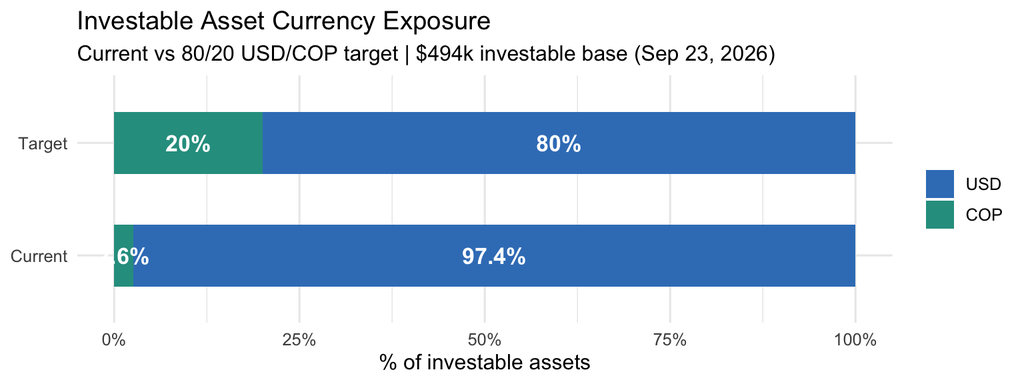

## 5-Year Net Worth Projections

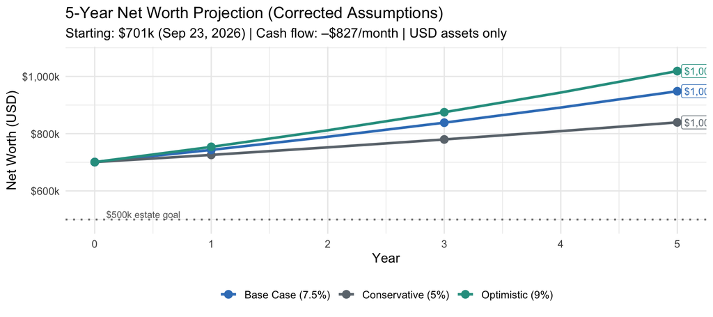

**Net Worth at Key Milestones**

Corrected: –$827/month cash flow | USD assets only

| Scenario | Projected Net Worth Year 0 | Projected Net Worth Year 1 | Projected Net Worth Year 3 | Projected Net Worth Year 5 |
| --- | --- | --- | --- | --- |
| Conservative (5%) | $701,000 | $726,000 | $780,000 | $839,000 |
| Base Case (7.5%) | $701,000 | $743,000 | $838,000 | $948,000 |
| Optimistic (9%) | $701,000 | $754,000 | $875,000 | $1,019,000 |

All three scenarios exceed the $500k estate goal through Year 5. Growth is driven by investment returns on the $494k investable base (updated Sep 23, 2026; projected at 7.5% base case) rather than new contributions — since income and spending are roughly break-even.

## Monthly Allocation Recommendation

**This Month’s Allocation**

Total deployable: $5,200 from liquid reserve

[output not shown]

## Top COP Investment Vehicles

**COP Vehicle Ranking**

Colombia CPI: 5.5 % | TES 10Y real yield: 5.7 % | COP/USD: 3,274

| Vehicle | Type | Nominal Yield | Real Yield | Risk | Fogafin | Score<sup>1</sup> |
| --- | --- | --- | --- | --- | --- | --- |
| BBVA CDT 360 Days | cdt | 10.5% | 4.7% | minimal | ✓ | 2.90 |
| Bancolombia CDT 360 Days | cdt | 10.2% | 4.5% | minimal | ✓ | 2.78 |
| TES Colombia 5-Year Government Bond | government_bond | 11.2% | 5.4% | low | — | 2.76 |
| TES Colombia 30-Year Government Bond | government_bond | 12% | 6.2% | low | — | 2.76 |
| Ecopetrol Corporate Bond (COP) | corporate_bond | 13% | 7.1% | moderate | — | 2.74 |
| BBVA CDT 180 Days | cdt | 10% | 4.3% | minimal | ✓ | 2.71 |
| TES Colombia 10-Year Government Bond | government_bond | 11.5% | 5.7% | low | — | 2.57 |
| Bancolombia Senior Bond | corporate_bond | 12.5% | 6.6% | moderate | — | 2.55 |

<sup>1</sup> Score = risk-adjusted real yield + liquidity + Fogafin + COP momentum

- **BBVA CDT 360 Days** — 10.5% nominal / 4.7% real, minimal risk, Fogafin-insured
- **Bancolombia CDT 360 Days** — 10.2% nominal / 4.5% real, minimal risk, Fogafin-insured
- **TES Colombia 5Y** — 11.2% nominal / 5.4% real, government bond, no bank counterparty risk

## Top USD ETF Opportunities

**Global ETF Opportunities — Indicator-Adjusted**

Screening as of September 23, 2026 | All modifiers neutral today

| Symbol | Market / Theme | Category | Score<sup>1</sup> | Conviction |
| --- | --- | --- | --- | --- |
| INDA | India | Country ETF | 3.83 | Attractive, monitor closely |
| EWJ | Japan | Country ETF | 3.69 | Attractive, monitor closely |
| GRID | Electric grid infrastructure | Infrastructure | 3.54 | Attractive, monitor closely |
| URA | Uranium and nuclear fuel | Commodity theme | 3.44 | Watchlist or tactical |
| EWQ | France | Country ETF | 3.36 | Watchlist or tactical |
| EWL | Switzerland | Country ETF | 3.36 | Watchlist or tactical |
| EWU | United Kingdom | Country ETF | 3.30 | Watchlist or tactical |
| FAN | Wind energy | Energy transition | 3.30 | Watchlist or tactical |
| ITA | U.S. aerospace and defense benchmark | U.S. sector benchmark | 3.29 | Watchlist or tactical |
| WOOD | Global timber and forestry | Commodity theme | 3.26 | Watchlist or tactical |

## Falsification Triggers

The following conditions would change the current recommendation:

[output not shown]

## Disclaimer

*This document is generated by the Global Investment Advisor research system. It is research and analysis only, not personalized financial advice. Past performance is not indicative of future results. All projections are illustrative scenarios, not guarantees. Consult a qualified financial advisor before making investment decisions.*

*Report generated: 2026-09-23 17:46 EDT*